# Estudios de Informática, Multimedia y Telecomunicaciones

Una buena técnica que ayuda a entender los grupos que se han formado, es analizar las características de cada grupo:

- Grupo 1: Valores del pétalo alto. Longitud del sépalo alto.
- Grupo 2: Valores del pétalo bajos. Longitud del sépalo bajo.
- Grupo 3: Valores intermedios salvo en el ancho del sépalo que es intermedio.

Vamos a ahora a estudiar los conjuntos que se han obtenido con 2 clusters:

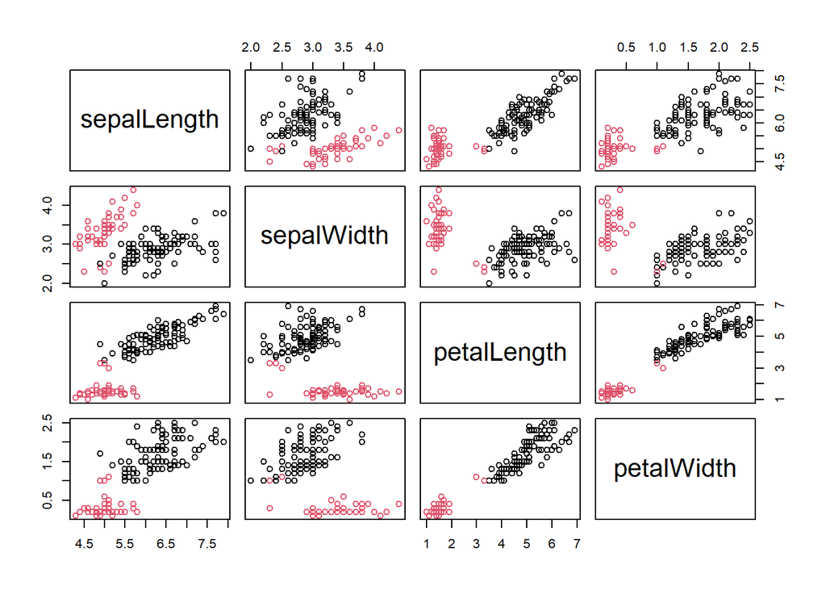

```r
cl2 <- kmeans(flores_data, 2)
with(flores_data, pairs(flores_data, col=c(1:4)[cl2$cluster]))
```

Esto último lo podemos comprobar usando únicamente las dos características relacionadas con el pétalo:

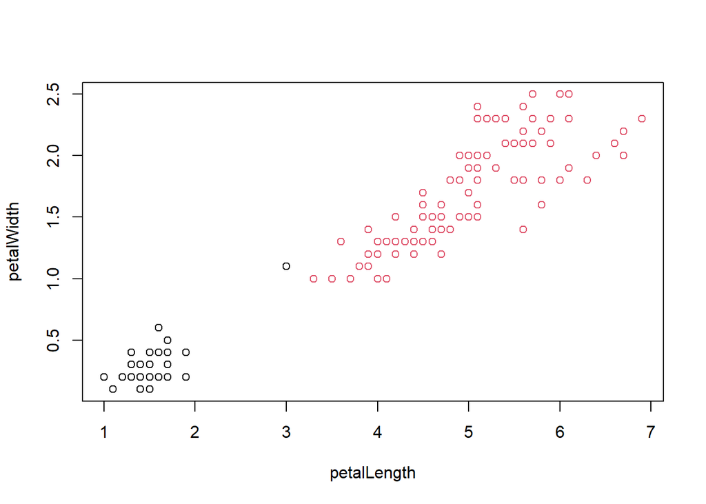

```r
cl2b <- kmeans(flores_data[c(3,4)], 2)
plot(flores_data[c(3,4)], col=cl2b$cluster)
```

## 4.4 Respuesta ejercicio 3

## 4.5 Carga, resumen, explicación, preparación y análisis de los datos

### 4.5.1 Carga de los datos

En este primer punto lo que debemos de hacer es la carga de los datos, un resumen de lo que hemos leído, una explicación de los mismos, preparar los datos para el modelo y realizar un análisis de los mismos.

Por lo tanto, lo primero que debemos hacer es la carga del archivo clientes.csv:

```r
df_clientes = read.csv("./data/clientes.csv", stringsAsFactors = TRUE)
colnames(df_clientes) = c("CustomerID", "Genr", "Age", "Income", "Spending_Score")
head(df_clientes)
```

```
##   CustomerID   Genr Age Income Spending_Score
## 1          1   Male  19     15             39
## 2          2   Male  21     15             81
## 3          3 Female  20     16              6
## 4          4 Female  23     16             77
## 5          5 Female  31     17             40
## 6          6 Female  22     17             76
```

### 4.5.2 Resumen de los datos

Resumen de la estructura del dataset:

```r
str(df_clientes)
```

```
## 'data.frame':    200 obs. of  5 variables:
##  $ CustomerID    : int  1 2 3 4 5 6 7 8 9 10 ...
##  $ Genr          : Factor w/ 2 levels "Female","Male": 2 2 1 1 1 1 1 1 2 1 ...
##  $ Age           : int  19 21 20 23 31 22 35 23 64 30 ...
##  $ Income        : int  15 15 16 16 17 17 18 18 19 19 ...
##  $ Spending_Score: int  39 81 6 77 40 76 6 94 3 72 ...
```

### 4.5.3 Explicación de los datos

Revisamos la descripción de las variables y si los tipos de variable se corresponden al que hemos cargado:

**CustomerID** integer - id del cliente.

**Genr** factor - género del cliente.

**Age** integer - edad del cliente.

**Income** integer - ingresos anuales del cliente, representado en k dólares (15 = 15000$)

**Spending_Score** integer - puntuación del gasto del cliente.

Vemos que tenemos 200 registros y 5 variables que los caracterizan.

Este dataset está formado por 4 variables numéricas y una variable categórica (el género).

### 4.5.4 Preparación de los datos

Al hacer un uso posterior del algoritmo kmeans solo nos admite valores numéricos, es por ello que vamos a eliminar la columna género del dataset original. Además, vamos a analizar el cómo se agrupan los clientes según la edad, los ingresos y su puntación en el gasto, por lo que la columna CustomerID la podemos quitar del dataset, si se necesita en un futuro para identificar un elemento en particular podemos añadir dicha columna a posteriori:

```r
df_clientes_copy = df_clientes[c(3:5)]
str(df_clientes_copy)
```

```
## 'data.frame':    200 obs. of  3 variables:
##  $ Age           : int  19 21 20 23 31 22 35 23 64 30 ...
##  $ Income        : int  15 15 16 16 17 17 18 18 19 19 ...
##  $ Spending_Score: int  39 81 6 77 40 76 6 94 3 72 ...
```

Comprobamos que no haya datos sin valores:

```r
colSums(is.na(df_clientes_copy))
```

```
##            Age         Income Spending_Score
##              0              0              0
```

De la anterior ejecución vemos que todos los campos tienen valores. Realizamos un summary del dataset resultante para hacernos una idea del conjunto de datos que vamos a manejar, es decir, cuáles son los valores mínimos/máximos, ver si a priori hay outliers…

```r
summary(df_clientes_copy)
```

```
##       Age            Income       Spending_Score
##  Min.   :18.00   Min.   : 15.00   Min.   : 1.00
##  1st Qu.:28.75   1st Qu.: 41.50   1st Qu.:34.75
##  Median :36.00   Median : 61.50   Median :50.00
##  Mean   :38.85   Mean   : 60.56   Mean   :50.20
##  3rd Qu.:49.00   3rd Qu.: 78.00   3rd Qu.:73.00
##  Max.   :70.00   Max.   :137.00   Max.   :99.00
```

Como podemos observar, las variables Age, Income y Spending_Score siempre toman valores positivos, lo cual tiene todo el sentido del mundo, no sería posible ver a alguien con -8 años/ -15000$ de ingresos/ -50 puntos de gasto. Además, todas las variables tienen un rango de valores bastente comunes, sin embargo, en la variable Income hay mucha diferencia entre el tercer cuartil y el valor máximo, comprobamos si hay outliers en dicha variable:

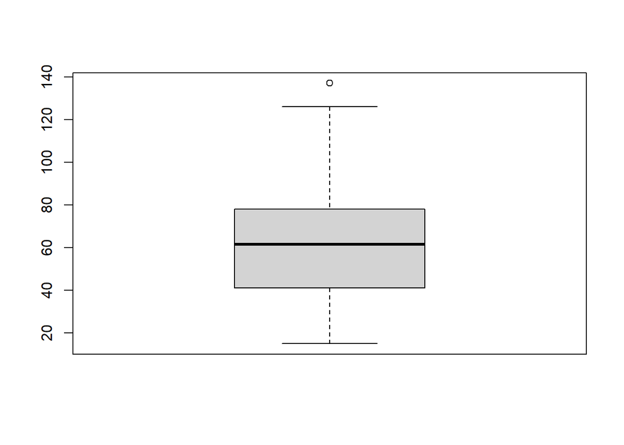

```r
library(ggplot2)

boxplot(df_clientes_copy$Income)
```

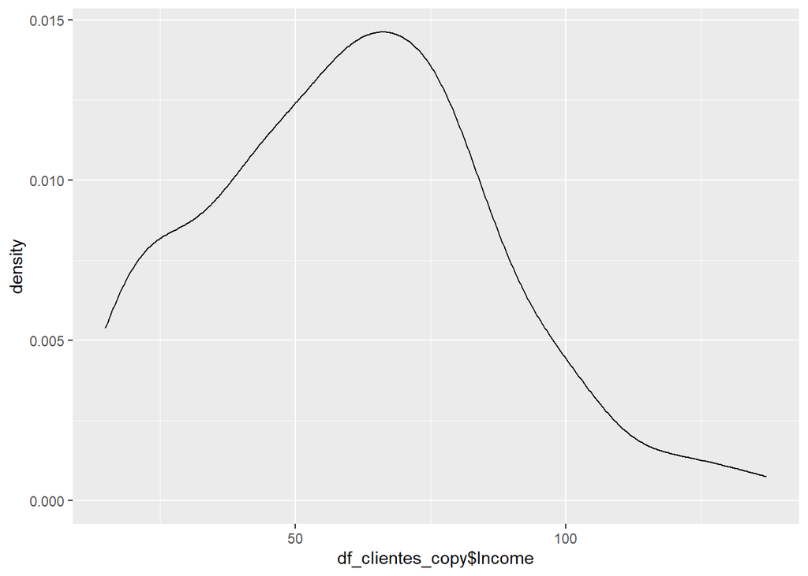

```r
ggplot(mapping = aes(x=df_clientes_copy$Income)) + geom_density()
```

Observamos según el boxplot, que sí que tenemos un punto que es outlier, cuyo valor es el máximo 137. Sin embargo, a la hora de ver la distribución de la variable vemos que para nada es un outlier, es decir, no hay una anomalía, por lo tanto, podemos asegurar que dicho valor es correcto, ya que puede ser que alguien ingrese 137000$.

El siguiente paso es preparar los datos para que puedan ser utilizados por el algoritmo kmeans, un aspecto importante de dicho algoritmo es que tiene en cuenta las distancias entre puntos, por lo que, no es lo mismo medir la distancia como la edad que va de 18 a 70 años, a como lo hace los ingresos anuales que van de 15000 a 137000 dólares.

Es por ello, que primero debemos normalizar el dataset:

```r
df_clientes_copy = scale(df_clientes_copy)
head(df_clientes_copy)
```

```
##             Age    Income Spending_Score
## [1,] -1.4210029 -1.734646     -0.4337131
## [2,] -1.2778288 -1.734646      1.1927111
## [3,] -1.3494159 -1.696572     -1.7116178
## [4,] -1.1346547 -1.696572      1.0378135
## [5,] -0.5619583 -1.658498     -0.3949887
## [6,] -1.2062418 -1.658498      0.9990891
```

### 4.5.5 Análisis de los datos

Finalmente, para terminar con esta primera fase, vamos a hacer un análisis de dichas variables, es decir, los ingresos respecto a la edad:

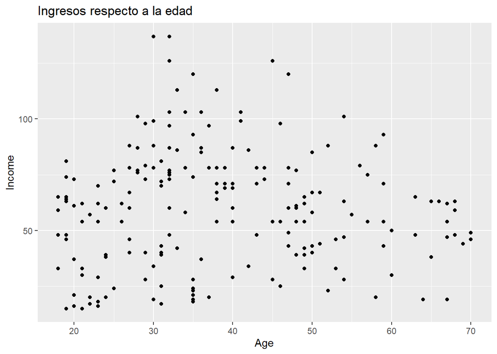

```r
ggplot(df_clientes, aes(x = Age, y = Income)) +
  geom_point() +
  ggtitle("Ingresos respecto a la edad")
```

Como podemos ver no hay una distinción clara de grupos, sin embargo, aquella población de mediana edad entre 30 y 50 años tienen unos ingresos de media más elevados que la población joven y que la población de mayores, pero a priori no podemos hacer una distinción clara entre grupos.

Por otro lado, podemos ver cómo varía la puntuación de gatos respecto a la edad:

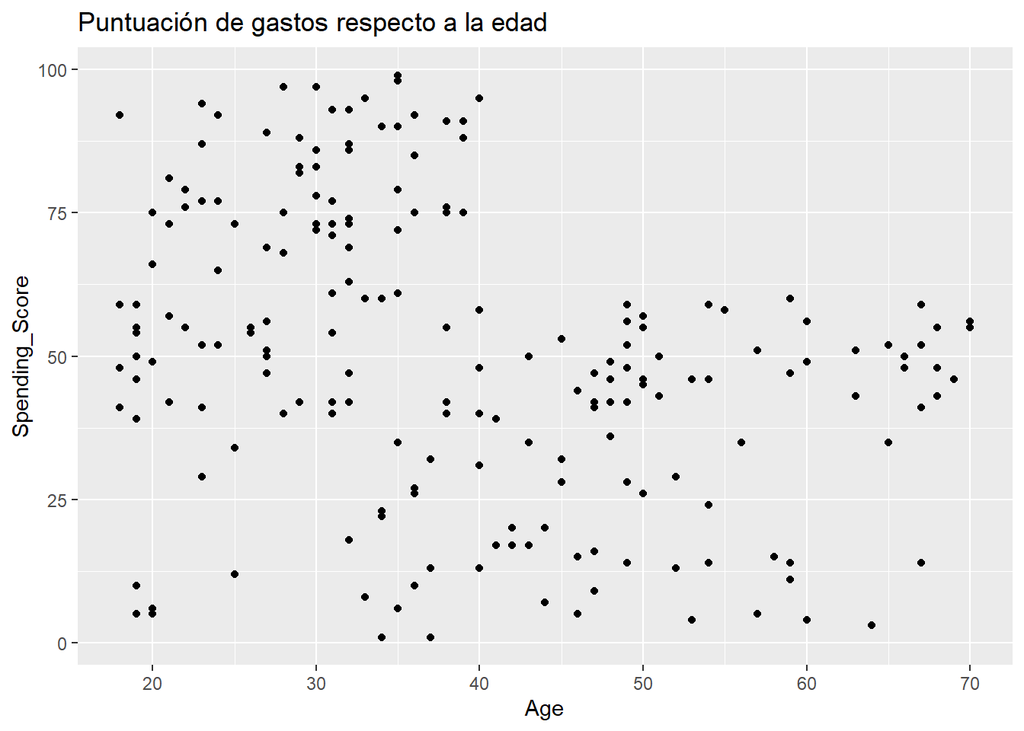

```r
ggplot(df_clientes, aes(x = Age, y = Spending_Score)) +
  geom_point() +
  ggtitle("Puntuación de gastos respecto a la edad")
```

Analizando la anterior gráfica podemos ver que podríamos tener a priori 4/5 grupos: población joven con una baja puntuación de gastos, población joven con una puntuación de gastos media, población joven con una puntuación de gastos elevada, población de mediana/mayor edad con una baja puntuación de gastos y población de mediana/mayor edad con una puntuación de gastos media.

Por último podemos analizar la relación entre ingresos y gastos:

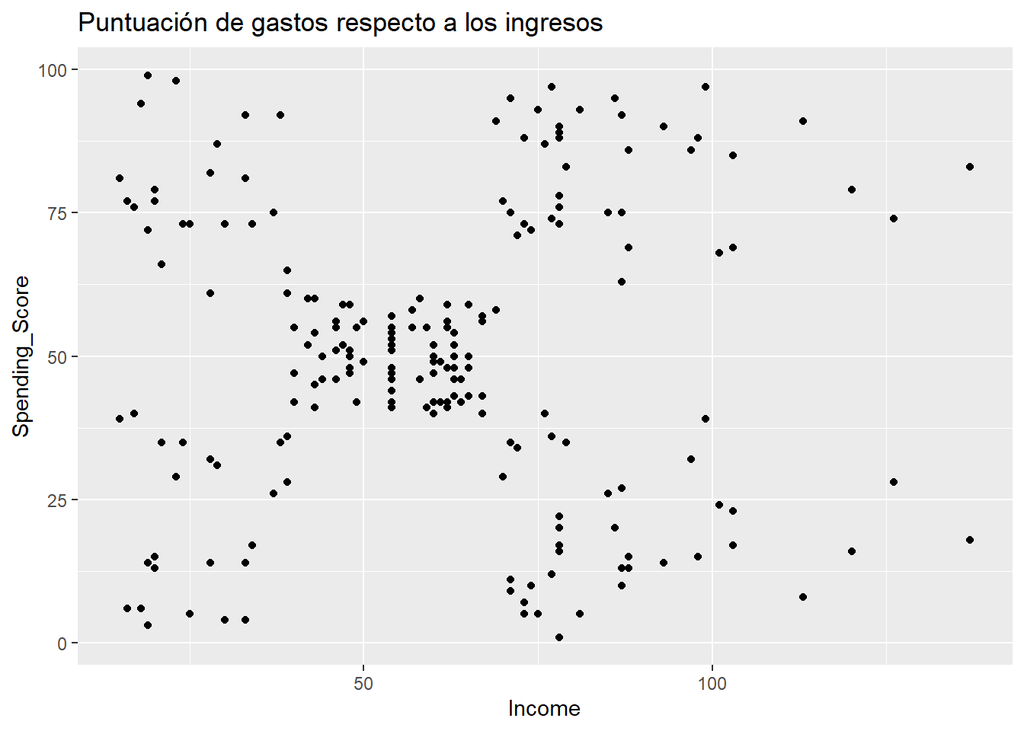

```r
ggplot(df_clientes, aes(x = Income, y = Spending_Score)) +
  geom_point() +
  ggtitle("Puntuación de gastos respecto a los ingresos")
```

La anterior gráfica es bastante curiosa porque podemos apreciar 5 grupos claramente: población que tiene unos ingresos bajos y su puntación de gasto es baja, ingresos bajos y gasto elevado, ingresos medio y gasto medio, ingresos altos y gastos bajos, ingresos altos y gastos altos.

## 4.6 Aplicación del algoritmo k-means con diferentes k.

Del anterior análisis de los datos podemos apreciar que a priori va a haber 5 grupos según los ingresos y los gastos, pero una cosa es lo que a priori podemos tener y luego lo que realmente es, por lo tanto, vamos a aplicar el algoritmo de k-means con diferentes k para ver cómo se agrupan los elementos:

```r
library(cluster)
```

Pero antes, vamos a calcular el número de clústers ideales para poder realizar nuestro modelo. Esto lo vamos a hacer de dos formas, la primera calculando la silhouette. Cabe destacar que calculamos el valor de la silueta x veces para cada modelo, esto es así porque dicho valor cambia todo el rato, al calcularlo x veces podemos hacer una media y que los “mejores clusters” se mantengan independientemente de las veces que se ejecute:

```r
# Método que nos devuelve el valor medio de la silueta para un rango de clústers y de iteraciones sobre el mismo clúster
kmeans_silhouette = function(df, minCluster = 2, maxCluster = 10, maxIterations = 10) {

  if (minCluster <= maxCluster & minCluster > 1) {
    resultados = rep(0, maxCluster)

    for (i in c(minCluster:maxCluster)) {
      resultado = rep(0, maxIterations)

      for (j in c(1:maxIterations)) {
        fit = kmeans(df, i)
        y_cluster = fit$cluster
        sk = silhouette(y_cluster, daisy(df))

        # Como el valor de la silueta puede cambiar de una iteración a otra, calculamos su valor medio
        resultado[j] = mean(sk[,3])
      }
      resultados[i] = mean(resultado)
    }
    return(resultados)

  } else {
    print("ERROR: minCluster debe ser menor que maxCluster y mayor que 1")
  }
}
```

Una vez definido el método que nos va a permitir calcular el valor de la silueta medio para cada modelo, obtenemos la siguiente gráfica:

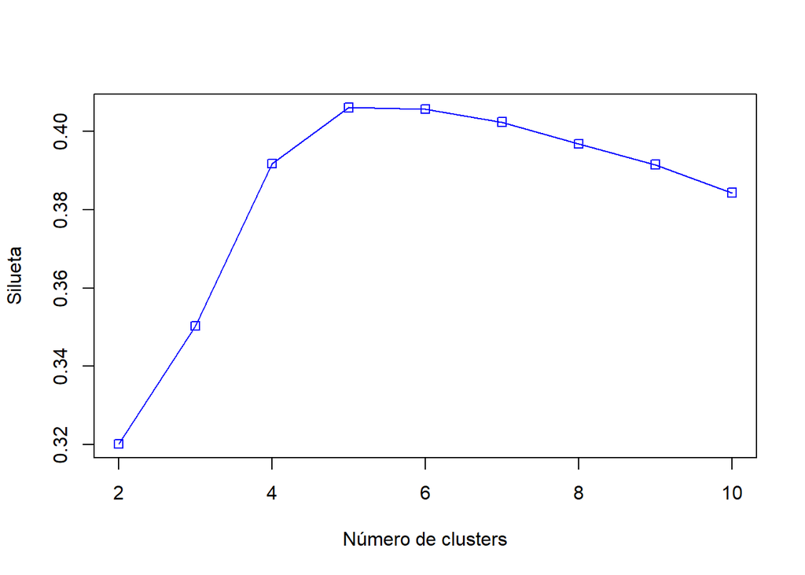

```r
minCluster = 2
maxCluster = 10
maxIterations = 2000

mean_silhouette = kmeans_silhouette(df_clientes_copy, minCluster, maxCluster, maxIterations)

plot(minCluster:maxCluster, mean_silhouette[minCluster:maxCluster],type="o",col="blue",pch=0,xlab="Número de clusters",ylab="Silueta")
```

Tal y como podemos observar, los modelos que mejor silueta proporcionan son cuando tienen 5, 6 y 7 clústers. Si nos ponemos un poco más precisos, podríamos decir que los dos mejores modelos son cuando tienen 5 y 6 clústers ya que cuando tiene 7 el modelo tiene una silueta menor que en los dos casos anteriores.

## 4.7 Análisis de calidad del agrupamiento

Una vez que ya hemos aplicado el kmeans con diferentes k, para así saber cuántos clusters proporciona una mayor silueta, lo siguiente que debemos hacer es saber cómo de bueno son los agrupamientos, lo cual nos va a definir también cuántos clústers serían lo ideal.

Esto los conseguimos con la menor suma de los cuadrados de las distancias de los puntos de cada grupo con respecto a su centro (withinss), con la mayor separación entre centros de grupos (betweenss):

```r
# Método que nos devuelve el valor medio del tot.withinss para un rango de clústers y de iteraciones sobre el mismo clúster
kmeans_totWithinss = function(df, minCluster = 2, maxCluster = 10, maxIterations = 10) {

  if (minCluster <= maxCluster & minCluster > 1) {
    resultados = rep(0, maxCluster)

    for (i in c(minCluster:maxCluster))
    {
      resultado = rep(0, maxIterations)

      for (j in c(1:maxIterations)) {
        fit = kmeans(df, i)
        resultado[j] = fit$tot.withinss
      }

      resultados[i] = mean(resultado)
    }
    return(resultados)

  } else {
     print("ERROR: minCluster debe ser menor que maxCluster y mayor que 1")
  }
}
```

Una vez definido el método que nos devuelve el valor medio de withinss para cada modelo, obtenemos la siguiente gráfica:

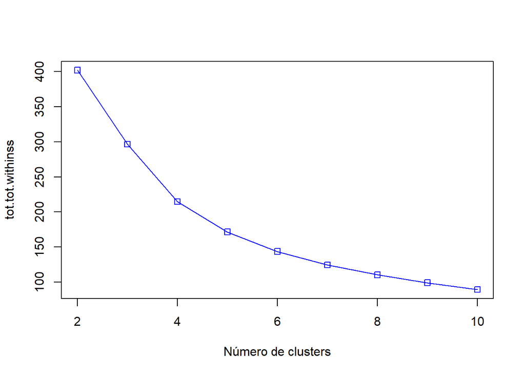

```r
mean_totWithinss = kmeans_totWithinss(df_clientes_copy, minCluster, maxCluster, maxIterations)

plot(minCluster:maxCluster,mean_totWithinss[minCluster:maxCluster],type="o",col="blue",pch=0,xlab="Número de clusters",ylab="tot.tot.withinss")
```

Tal y como podemos observar en la anterior ilustración, los mejores agrupamientos son aquellos en los que el error es mínimo (se ha explicado antes), lógicamente a mayor número de clusters, menor error vamos a tener ya que el modelo va a ser muy específico, de hecho, si cada punto fuera un clúster independiente a priori sería lo mejor, porque reduciríamos el error a 0, pero esto no es lo ideal de un problema de minería, no buscamos crear modelos muy específicos, sino que más bien buscamos generalizar.

Para seguir determinando la calidad de los modelos podemos tener en cuenta la distancia entre centro de grupos, lo que se llama betweenss, a mayor distancia más separación hay entre los grupos, por lo que mejor es el modelo:

```r
# Método que nos devuelve el valor medio de la betweenss para un rango de clústers y de iteraciones sobre el mismo clúster
kmeans_betweenss = function(df, minCluster = 2, maxCluster = 10, maxIterations = 10) {

  if (minCluster <= maxCluster & minCluster > 1) {
    resultados = rep(0, maxCluster)

    for (i in c(minCluster:maxCluster))
    {
      resultado = rep(0, maxIterations)

      for (j in c(1:maxIterations)) {
        fit = kmeans(df, i)
        resultado[j] = fit$betweenss
      }

      resultados[i] = mean(resultado)
    }
    return(resultados)

  } else {
     print("ERROR: minCluster debe ser menor que maxCluster y mayor que 1")
  }
}
```

Una vez definido el método que nos devuelve el valor medio de betweenss para cada modelo, obtenemos la siguiente gráfica:

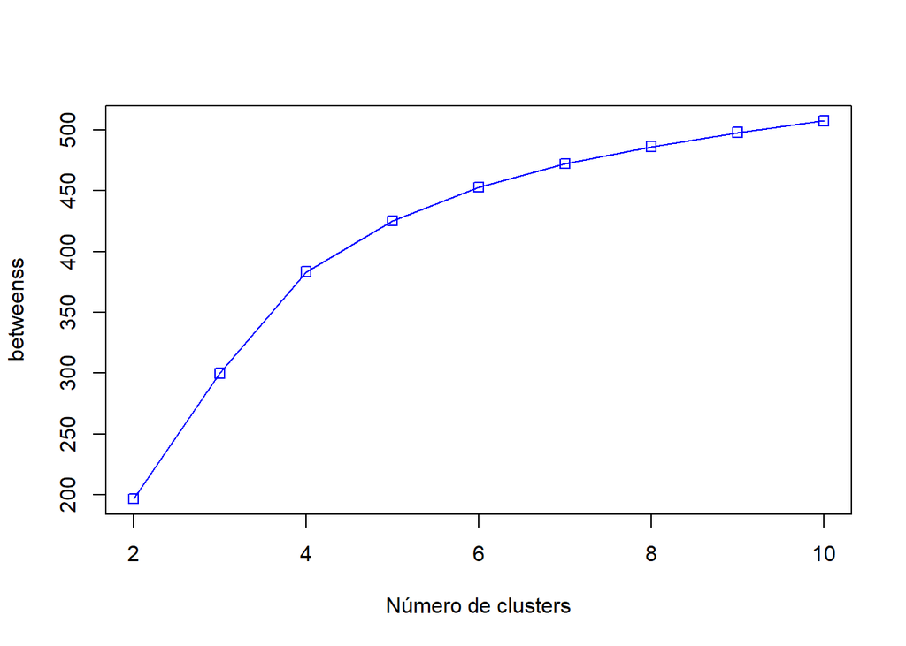

```r
mean_betweenss = kmeans_betweenss(df_clientes_copy, minCluster, maxCluster, maxIterations)

plot(minCluster:maxCluster,mean_betweenss[minCluster:maxCluster],type="o",col="blue",pch=0,xlab="Número de clusters",ylab="betweenss")
```

Una vez que ya hemos visto qué modelos presentan una mejor calidad de agrupamiento dependiendo del número de clusters, vamos a realizar el análisis tanto para un modelo de kmeans con un k igual a 5 e igual a 6.

Lo primero que debemos de hacer es crear ambos modelos:

```r
set.seed(0)
clientes_kmeans_k5 = kmeans(df_clientes_copy, 5)
clientes_kmeans_k6 = kmeans(df_clientes_copy, 6)
```

Lo segundo que vamos a hacer es calcular la silueta de cada modelo:

```r
set.seed(0)
clientes_kmeans_k5_silhouette = kmeans_silhouette(df_clientes_copy, 5, 5, 1)[5]
clientes_kmeans_k6_silhouette = kmeans_silhouette(df_clientes_copy, 6, 6, 1)[6]
cat("La silueta cuando el número de clusters es igual a 5 es: ", clientes_kmeans_k5_silhouette)
```

```
## La silueta cuando el número de clusters es igual a 5 es:  0.4166434
```

```r
cat("La silueta cuando el número de clusters es igual a 6 es: ", clientes_kmeans_k6_silhouette)
```

```
## La silueta cuando el número de clusters es igual a 6 es:  0.4274281
```

Lo tercero que vamos a realizar es calcular el calidad de cada modelo respecto a su withinss:

```r
set.seed(0)
clientes_kmeans_k5_totWithinss = kmeans_totWithinss(df_clientes_copy, 5, 5, 1)[5]
clientes_kmeans_k6_totWithinss = kmeans_totWithinss(df_clientes_copy, 6, 6, 1)[6]
cat("El withinss total cuando el número de clusters es igual a 5 es: ", clientes_kmeans_k5_totWithinss)
```

```
## El withinss total cuando el número de clusters es igual a 5 es:  167.4063
```

```r
cat("El withinss total cuando el número de clusters es igual a 6 es: ", clientes_kmeans_k6_totWithinss)
```

```
## El withinss total cuando el número de clusters es igual a 6 es:  133.199
```

Lo cuarto que vamos a hacer es calcular el calidad de cada modelo respecto a su betweenss:

```r
set.seed(0)
clientes_kmeans_k5_betweenss = kmeans_betweenss(df_clientes_copy, 5, 5, 1)[5]
clientes_kmeans_k6_betweenss = kmeans_betweenss(df_clientes_copy, 6, 6, 1)[6]
cat("La betweenss total cuando el número de clusters es igual a 5 es: ", clientes_kmeans_k5_betweenss)
```

```
## La betweenss total cuando el número de clusters es igual a 5 es:  429.5937
```

```r
cat("La betweenss total cuando el número de clusters es igual a 6 es: ", clientes_kmeans_k6_betweenss)
```

```
## La betweenss total cuando el número de clusters es igual a 6 es:  463.801
```

Una vez que tenemos todas las medidas, debemos saber que a mayor distancia a los centros de cada cluster es mejor y a menor distancia entre los puntos de un clúster a su centro también es mejor, por lo que a priori presenta una mayor calidad del modelo cuando tenemos 6 clústers.

Es por ello, que vamos a analizar los resultados obtenidos en primer lugar para un modelo con 5 clústers y luego para un modelo con 6 clústers.

## 4.8 Interpretación de los clústers

Lo primero que debemos observar es el cómo se han dividido los grupos por pares de variables, al tener tres variables podríamos hacer un gráfico tridimensional, pero se ve más claro en un gráfico en dos dimensiones.

El primer gráfico representa los grupos según el ingreso que tienen respecto a la edad:

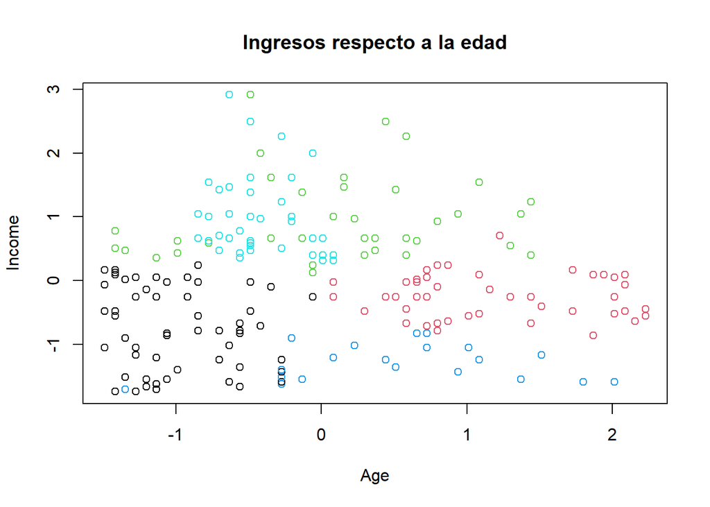

```r
plot(df_clientes_copy[,c(1,2)], col=clientes_kmeans_k5$cluster, main="Ingresos respecto a la edad")
```

Cabe destacar que si en un gráfico hay grupos mezclados que a priori no tendría mucho sentido, es porque falta analizar el resto de gráficos (diferentes puntos de vista), por lo que ahora vamos a sacar unas primeras conclusiones y al final de todo el análisis tendremos ya las conclusiones definitivas.

Del anterior gráfico, podemos ver como es lógico que tenemos 5 grupos ya que estamos analizando primero el modelo kmean con una k igual a 5.

Podríamos concluir a primera vista que tenemos 3 grupos claros:

- Aquellos que son jóvenes y tienen unos ingresos bajos. (grupo negro)
- Mediana/tercera edad con ingresos muy bajos. (grupo azul oscuro)
- Mediana/tercera edad con ingresos bajos/medios. (grupo rojo)

Sin embargo dos grupos se mezclan (verde y azul claro), los primeros son gente de mediana/tercera edad con unos ingresos medios/elevados y los segundo son gente joven con unos ingresos medios/elevados.

El siguiente gráfico hace referencia a los gastos según la edad:

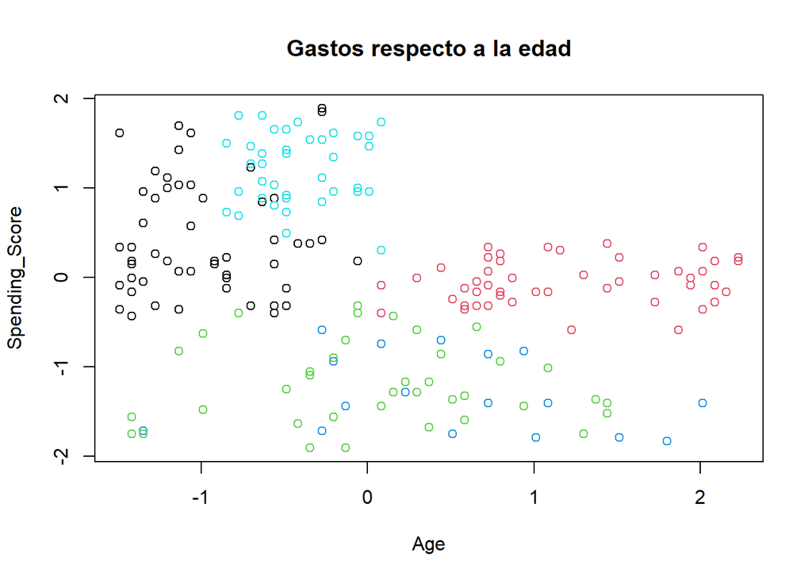

```r
plot(df_clientes_copy[,c(1,3)], col=clientes_kmeans_k5$cluster, main="Gastos respecto a la edad")
```

Al igual que sucedía con los ingresos sí que podemos distinguir tres grupos claramente:

- Aquellos jóvenes que tienen unos gastos medios/elevados. (grupo negro)
- Aquellos jóvenes de una edad superior a los anteriores con unos gastos elevados. (grupo azul claro)
- Gente de mediana/tercera edad con unos gastos medios. (grupo rojo)

Sin embargo, no podemos distinguir desde este punto de vista dos grupos: - Gente de mediana/tercera edad con unos gastos medios/bajos (grupo azul oscuro) - Gente de mayoritariamente de mediana edad aunque también de tercera edad con unos gastos medios/bajos. (grupo verde)

Por último, tenemos los gastos respecto a los ingresos:

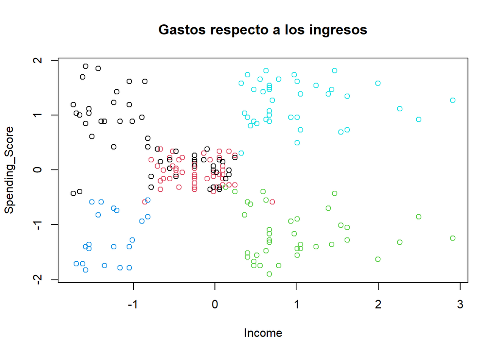

```r
plot(df_clientes_copy[,c(2,3)], col=clientes_kmeans_k5$cluster, main="Gastos respecto a los ingresos")
```

En este gráfico podemos distinguir mayoritariamente muy bien los grupos:

- Gente con unos gastos altos/medios e ingresos bajos/medios. (grupo negro)
- Gente con gastos bajos e ingresos bajos. (grupo azul oscuro)
- Gente con unos gastos medios e ingresos medios. (grupo rojo)
- Gente con gastos altos e ingresos altos. (grupo azul claro)
- Gente con gastos bajos e ingresos altos. (grupo verde)

### 4.8.1 Conclusiones respecto al algortimo de kmeans con una k = 5

Una vez que hemos analizado los clúster cuando tenemos 5 grupos, obtenemos las siguiente conclusiones:

- Respecto al grupo negro, son jóvenes que tienen unos ingresos bajos y sus gastos son medios y elevados.
- Respecto al grupo azul claro, son jóvenes que tienen unos ingresos medios/elevados y unos gastos elevados.
- Respecto al grupo rojo, son gente de mediana/tercera edad con unos ingresos medios/bajos y unos gastos medios.
- Respecto al grupo azul oscuro, son gente de mediana/tercera edad con unos ingresos muy bajos y unos gastos bajos.
- Respecto al grupo verde, son gente de mediana/tercera edad con ingresos medios/elevados y unos gastos medios/bajos.

Una vez obtenidas las conclusiones para el algoritmo kmeans con una k = 5, vamos a hacer lo mismo para una k = 6

El primer gráfico representa los grupos según el ingreso que tienen respecto a la edad:

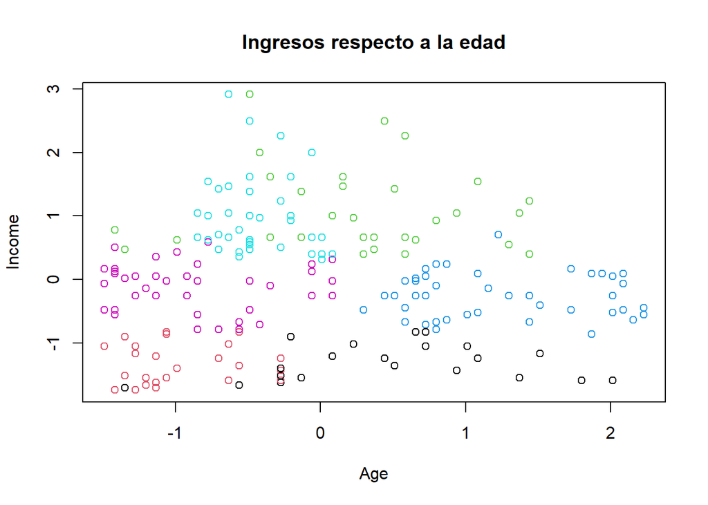

```r
plot(df_clientes_copy[,c(1,2)], col=clientes_kmeans_k6$cluster, main="Ingresos respecto a la edad")
```

Lógicamente al tener una k = 6 obtenemos 6 clúster, los cuales son:

- Jóvenes con unos ingresos medios. (grupo rosa)
- Jóvenes con unos ingresos bajos. (grupo rojo)
- Gente joven/mediana edad con ingresos elevados. (grupo azul claro)
- Gente de mediana/tercera edad con ingresos elevados. (grupo verde)
- Gente de mediana/tercera edad con ingresos medios. (grupo azul oscuro)
- Gente de mediana/tercera edad con ingresos bajos. (grupo negro)

El siguiente gráfico hace referencia a los gastos según la edad:

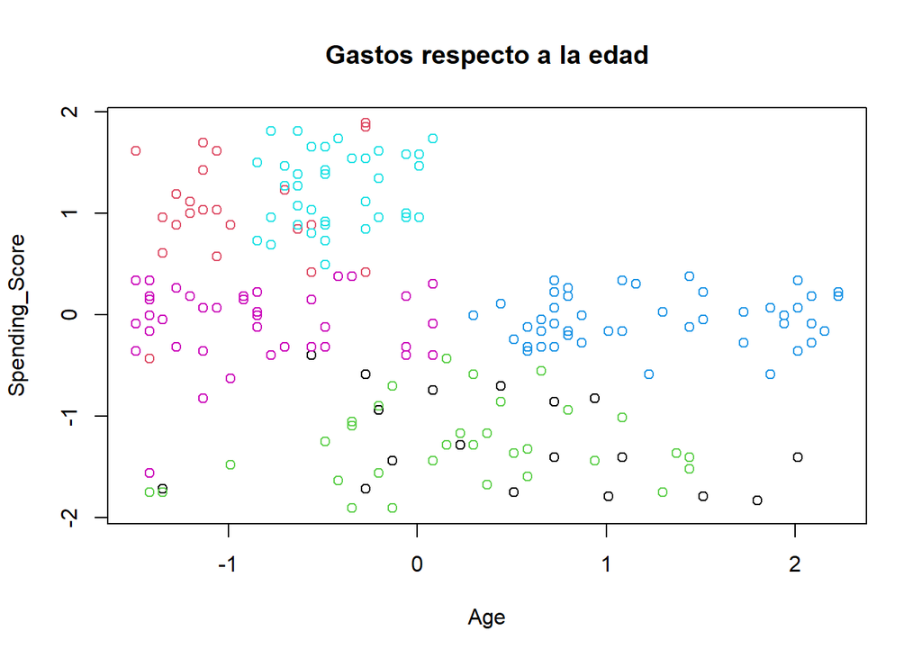

```r
plot(df_clientes_copy[,c(1,3)], col=clientes_kmeans_k6$cluster, main="Gastos respecto a la edad")
```

Del gráfico anterior obtenemos las siguiente información:

- Jóvenes con gastos elevados. (grupo rojo)
- Jóvenes con gastos medios. (grupo rosa)
- Gente joven/mediana edad con gastos elevados. (grupo azul claro)
- Gente de mediana/tercera edad con gastos medios. (grupo azul oscuro)
- Gente de mediana/tercera edad con gastos bajos. (grupo negro)
- Gente de mediana/tercera edad con gastos bajos. (grupo verde)

Cabe destacar que los dos últimos grupos no se ve una buena separación entre ellos, es más están mezclados, pero como veremos acontinuación es solamente porque coinciden en el rango de edad y el nivel de gasos.

Por último, tenemos los gastos respecto a los ingresos:

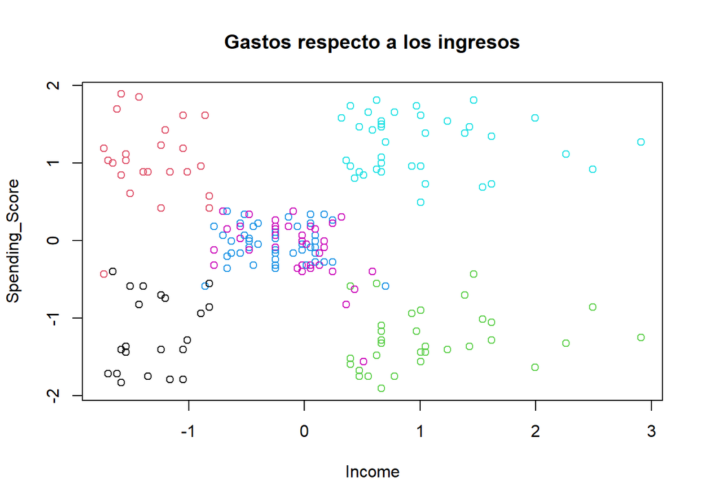

```r
plot(df_clientes_copy[,c(2,3)], col=clientes_kmeans_k6$cluster, main="Gastos respecto a los ingresos")
```

Respecto al anterior gráfico obtenemos la siguiente información:

- Gente que tiene unos ingresos bajos y unos gastos elevados. (grupo rojo)
- Gente que tiene unos ingresos bajos y unos gastos bajos. (grupo negro)
- Gente que tiene unos ingresos medios y unos gastos medios. (grupo azul oscuro)
- Gente que tiene unos ingresos medios y unos gastos medios. (grupo rosa)
- Gente que tiene unos ingresos elevados y unos gastos elevados. (grupo azul claro)
- Gente que tiene unos ingresos elevados y unos gatos bajos. (grupo verde)

### 4.8.2 Conclusiones respecto al algortimo de kmeans con una k = 6

Una vez que hemos analizado los clúster cuando tenemos 6 grupos, obtenemos las siguiente conclusiones:

- Respecto al grupo rojo, son jóvenes que tienen unos ingresos bajos y unos gastos elevados.
- Respecto al grupo rosa, son jóvenes que tienen unos ingresos medios y gastos medios.
- Respecto al grupo azul claro, son gente joven/mediana edad con unos ingresos elevados y gastos elevados.
- Respecto al grupo negro, son gente de mediana/tercera edad con unos ingresos bajos y gastos bajos.
- Respecto al grupo azul oscuro, son gente de mediana/tercera edad con unos ingresos medios y gastos medios.
- Respecto al grupo verde, son gente de mediana/tercera edad con unos ingresos elevados y gastos bajos.